# Part I - (Ford GoBike System Data)

## Introduction

> This analysis is centered on the data set that includes information about individual rides made \ in a bike-sharing system covering the greater San Francisco

### | Univariate Exploration

- What is the average time a rider spends on a bike?
- what Distribution of the number of trips by gender ?
- What is the total number of flights according to the type of members?
- How many users shared their data ?
- What is the age distribution on the number of trips?
- What is the Total trips during the weekday?

### || Bivariate Exploration

- what is the Relationship between duration the trip and Every type of user ?
- comparison of trips on weekdays vs user type, and member gender?
- What is the relationship between age and the duration of the trip?
- What is the distribution of user types and gender

### ||| Multivariate Exploration

- Is there a difference in the Mean Trip Duration of the Weekdays with the types of users?
- Is there a difference in the Mean Trip Duration of the Weekdays with the Member Gender?
- Is there a difference in the average duration of the trip during the hours of the day with the types of users?
- Is there a difference in the average duration of the trip during the hours of the day with the types of gender of the users?

## Preliminary Wrangling

```python
# import all packages and set plots to be embedded inline
import numpy as np
import pandas as pd
import matplotlib
import matplotlib.pyplot as plt
import seaborn as sb
%matplotlib inline
from matplotlib import rcParams
import datetime
```

> Load in your dataset and describe its properties through the questions below. Try and motivate your exploration goals through this section.

```python
# Read the data from a CSV file
df_bike = pd.read_csv('201902-fordgobike-tripdata.csv')
print(df_bike.shape)
df_bike.head(5)
```

```
(183412, 16)
```

|  | duration_sec | start_time | end_time | start_station_id | start_station_name | start_station_latitude | start_station_longitude | end_station_id | end_station_name | end_station_latitude | end_station_longitude | bike_id | user_type | member_birth_year | member_gender | bike_share_for_all_trip |
| --- | --- | --- | --- | --- | --- | --- | --- | --- | --- | --- | --- | --- | --- | --- | --- | --- |
| 0 | 52185 | 2019-02-28 17:32:10.1450 | 2019-03-01 08:01:55.9750 | 21.0 | Montgomery St BART Station (Market St at 2nd St) | 37.789625 | -122.400811 | 13.0 | Commercial St at Montgomery St | 37.794231 | -122.402923 | 4902 | Customer | 1984.0 | Male | No |
| 1 | 42521 | 2019-02-28 18:53:21.7890 | 2019-03-01 06:42:03.0560 | 23.0 | The Embarcadero at Steuart St | 37.791464 | -122.391034 | 81.0 | Berry St at 4th St | 37.775880 | -122.393170 | 2535 | Customer | NaN | NaN | No |
| 2 | 61854 | 2019-02-28 12:13:13.2180 | 2019-03-01 05:24:08.1460 | 86.0 | Market St at Dolores St | 37.769305 | -122.426826 | 3.0 | Powell St BART Station (Market St at 4th St) | 37.786375 | -122.404904 | 5905 | Customer | 1972.0 | Male | No |
| 3 | 36490 | 2019-02-28 17:54:26.0100 | 2019-03-01 04:02:36.8420 | 375.0 | Grove St at Masonic Ave | 37.774836 | -122.446546 | 70.0 | Central Ave at Fell St | 37.773311 | -122.444293 | 6638 | Subscriber | 1989.0 | Other | No |
| 4 | 1585 | 2019-02-28 23:54:18.5490 | 2019-03-01 00:20:44.0740 | 7.0 | Frank H Ogawa Plaza | 37.804562 | -122.271738 | 222.0 | 10th Ave at E 15th St | 37.792714 | -122.248780 | 4898 | Subscriber | 1974.0 | Male | Yes |

```python
df_bike.info()
```

```
<class 'pandas.core.frame.DataFrame'>
RangeIndex: 183412 entries, 0 to 183411
Data columns (total 16 columns):
 #   Column                   Non-Null Count   Dtype
---  ------                   --------------   -----
 0   duration_sec             183412 non-null  int64
 1   start_time               183412 non-null  object
 2   end_time                 183412 non-null  object
 3   start_station_id         183215 non-null  float64
 4   start_station_name       183215 non-null  object
 5   start_station_latitude   183412 non-null  float64
 6   start_station_longitude  183412 non-null  float64
 7   end_station_id           183215 non-null  float64
 8   end_station_name         183215 non-null  object
 9   end_station_latitude     183412 non-null  float64
 10  end_station_longitude    183412 non-null  float64
 11  bike_id                  183412 non-null  int64
 12  user_type                183412 non-null  object
 13  member_birth_year        175147 non-null  float64
 14  member_gender            175147 non-null  object
 15  bike_share_for_all_trip  183412 non-null  object
dtypes: float64(7), int64(2), object(7)
memory usage: 22.4+ MB
```

```python
# count of unique values in each column
print(df_bike.nunique())
```

```
duration_sec                 4752
start_time                 183401
end_time                   183397
start_station_id              329
start_station_name            329
start_station_latitude        334
start_station_longitude       335
end_station_id                329
end_station_name              329
end_station_latitude          335
end_station_longitude         335
bike_id                      4646
user_type                       2
member_birth_year              75
member_gender                   3
bike_share_for_all_trip         2
dtype: int64
```

```python
#Check the types of users
df_bike.user_type.unique()
```

```
array(['Customer', 'Subscriber'], dtype=object)
```

```python
# Knowing the gender
df_bike.member_gender.unique()
```

```
array(['Male', nan, 'Other', 'Female'], dtype=object)
```

```python
#Check the values of those who shared their data
df_bike.bike_share_for_all_trip.unique()
```

```
array(['No', 'Yes'], dtype=object)
```

```python
# Total missing values in each column
df_bike.isna().sum()
```

```
duration_sec                  0
start_time                    0
end_time                      0
start_station_id            197
start_station_name          197
start_station_latitude        0
start_station_longitude       0
end_station_id              197
end_station_name            197
end_station_latitude          0
end_station_longitude         0
bike_id                       0
user_type                     0
member_birth_year          8265
member_gender              8265
bike_share_for_all_trip       0
dtype: int64
```

```python
#Check records that do not contain age or gender
df_bike[(df_bike['member_birth_year'].isna()) & (df_bike['member_gender'].isna()) ].isna().sum()
```

```
duration_sec                  0
start_time                    0
end_time                      0
start_station_id              2
start_station_name            2
start_station_latitude        0
start_station_longitude       0
end_station_id                2
end_station_name              2
end_station_latitude          0
end_station_longitude         0
bike_id                       0
user_type                     0
member_birth_year          8265
member_gender              8265
bike_share_for_all_trip       0
dtype: int64
```

```python
# Check for stations that do not have names
df_bike[(df_bike['start_station_id'].isna()) & (df_bike['start_station_name'].isna()) ].isna().sum()
```

```
duration_sec                 0
start_time                   0
end_time                     0
start_station_id           197
start_station_name         197
start_station_latitude       0
start_station_longitude      0
end_station_id             197
end_station_name           197
end_station_latitude         0
end_station_longitude        0
bike_id                      0
user_type                    0
member_birth_year            2
member_gender                2
bike_share_for_all_trip      0
dtype: int64
```

```python
# Find out if there is a way to recover the names and numbers of the stations

df_bike_list_miss_name = df_bike[['start_station_latitude','start_station_longitude']][(df_bike['start_station_id'].isna()) & (df_bike['start_station_name'].isna())].value_counts(['start_station_latitude','start_station_longitude'])
df_bike_list_miss_name = pd.DataFrame(df_bike_list_miss_name)
for i, row  in df_bike_list_miss_name.iterrows():
    rr = df_bike['start_station_id'][(df_bike['start_station_id'].notnull()) & (df_bike['start_station_name'].notnull()) & (df_bike['start_station_latitude']==i[0]) & (df_bike['start_station_longitude']==i[1])].count()
    print(rr ,i[0] ,i[1])
```

```
0 37.41 -121.96
0 37.4 -121.93
0 37.41 -121.94
0 37.41 -121.95
0 37.4 -121.94
0 37.39 -121.93
0 37.4 -121.92
0 37.42 -121.95
0 37.42 -121.96
0 37.42 -121.94
0 37.41 -121.93
0 37.38 -121.94
0 37.39 -121.92
0 37.41 -121.98
```

> Unfortunately, it is not possible to recover the **start_station_name** and **start_station_id**

```python
#Drop all missing values
df_bike.dropna(inplace=True)
```

```python
# check  Data Frame
df_bike.info()
```

```
<class 'pandas.core.frame.DataFrame'>
Int64Index: 174952 entries, 0 to 183411
Data columns (total 16 columns):
 #   Column                   Non-Null Count   Dtype
---  ------                   --------------   -----
 0   duration_sec             174952 non-null  int64
 1   start_time               174952 non-null  object
 2   end_time                 174952 non-null  object
 3   start_station_id         174952 non-null  float64
 4   start_station_name       174952 non-null  object
 5   start_station_latitude   174952 non-null  float64
 6   start_station_longitude  174952 non-null  float64
 7   end_station_id           174952 non-null  float64
 8   end_station_name         174952 non-null  object
 9   end_station_latitude     174952 non-null  float64
 10  end_station_longitude    174952 non-null  float64
 11  bike_id                  174952 non-null  int64
 12  user_type                174952 non-null  object
 13  member_birth_year        174952 non-null  float64
 14  member_gender            174952 non-null  object
 15  bike_share_for_all_trip  174952 non-null  object
dtypes: float64(7), int64(2), object(7)
memory usage: 22.7+ MB
```

```python
# fixing the dtypes problems.
df_bike.start_time = pd.to_datetime(df_bike.start_time)
df_bike.end_time = pd.to_datetime(df_bike.end_time)
df_bike.start_station_id = df_bike.start_station_id.astype(str)
df_bike.end_station_id = df_bike.end_station_id.astype(str)
df_bike.bike_id = df_bike.bike_id.astype(str)
#df_bike.member_birth_year= df_bike.member_birth_year.astype(int)
df_bike.user_type = df_bike.user_type.astype('category')
df_bike.bike_share_for_all_trip = df_bike.bike_share_for_all_trip.astype('category')
```

```python
#Adding a new column for the age is the age calculation value based on the time of data registration 2019
df_bike['age'] = (2019 - df_bike['member_birth_year'])
```

```python
df_bike.info()
```

```
<class 'pandas.core.frame.DataFrame'>
Int64Index: 174952 entries, 0 to 183411
Data columns (total 17 columns):
 #   Column                   Non-Null Count   Dtype
---  ------                   --------------   -----
 0   duration_sec             174952 non-null  int64
 1   start_time               174952 non-null  datetime64[ns]
 2   end_time                 174952 non-null  datetime64[ns]
 3   start_station_id         174952 non-null  object
 4   start_station_name       174952 non-null  object
 5   start_station_latitude   174952 non-null  float64
 6   start_station_longitude  174952 non-null  float64
 7   end_station_id           174952 non-null  object
 8   end_station_name         174952 non-null  object
 9   end_station_latitude     174952 non-null  float64
 10  end_station_longitude    174952 non-null  float64
 11  bike_id                  174952 non-null  object
 12  user_type                174952 non-null  category
 13  member_birth_year        174952 non-null  float64
 14  member_gender            174952 non-null  object
 15  bike_share_for_all_trip  174952 non-null  category
 16  age                      174952 non-null  float64
dtypes: category(2), datetime64[ns](2), float64(6), int64(1), object(6)
memory usage: 21.7+ MB
```

```python
df_bike.info()
```

```
<class 'pandas.core.frame.DataFrame'>
Int64Index: 174952 entries, 0 to 183411
Data columns (total 17 columns):
 #   Column                   Non-Null Count   Dtype
---  ------                   --------------   -----
 0   duration_sec             174952 non-null  int64
 1   start_time               174952 non-null  datetime64[ns]
 2   end_time                 174952 non-null  datetime64[ns]
 3   start_station_id         174952 non-null  object
 4   start_station_name       174952 non-null  object
 5   start_station_latitude   174952 non-null  float64
 6   start_station_longitude  174952 non-null  float64
 7   end_station_id           174952 non-null  object
 8   end_station_name         174952 non-null  object
 9   end_station_latitude     174952 non-null  float64
 10  end_station_longitude    174952 non-null  float64
 11  bike_id                  174952 non-null  object
 12  user_type                174952 non-null  category
 13  member_birth_year        174952 non-null  float64
 14  member_gender            174952 non-null  object
 15  bike_share_for_all_trip  174952 non-null  category
 16  age                      174952 non-null  float64
dtypes: category(2), datetime64[ns](2), float64(6), int64(1), object(6)
memory usage: 21.7+ MB
```

```python
df_bike.describe()
```

|  | duration_sec | start_station_latitude | start_station_longitude | end_station_latitude | end_station_longitude | member_birth_year | age |
| --- | --- | --- | --- | --- | --- | --- | --- |
| count | 174952.000000 | 174952.000000 | 174952.000000 | 174952.000000 | 174952.000000 | 174952.000000 | 174952.000000 |
| mean | 704.002744 | 37.771220 | -122.351760 | 37.771414 | -122.351335 | 1984.803135 | 34.196865 |
| std | 1642.204905 | 0.100391 | 0.117732 | 0.100295 | 0.117294 | 10.118731 | 10.118731 |
| min | 61.000000 | 37.317298 | -122.453704 | 37.317298 | -122.453704 | 1878.000000 | 18.000000 |
| 25% | 323.000000 | 37.770407 | -122.411901 | 37.770407 | -122.411647 | 1980.000000 | 27.000000 |
| 50% | 510.000000 | 37.780760 | -122.398279 | 37.781010 | -122.397437 | 1987.000000 | 32.000000 |
| 75% | 789.000000 | 37.797320 | -122.283093 | 37.797673 | -122.286533 | 1992.000000 | 39.000000 |
| max | 84548.000000 | 37.880222 | -121.874119 | 37.880222 | -121.874119 | 2001.000000 | 141.000000 |

```python
#Check abnormal values
df_bike['member_birth_year'][(df_bike['age']>105)].value_counts()
```

```
1900.0    53
1902.0    11
1901.0     6
1878.0     1
1910.0     1
Name: member_birth_year, dtype: int64
```

```python
#fix abnormal values As an input error (Boolean approximation)
df_bike['member_birth_year'] = df_bike['member_birth_year'].replace([1900], 1990)
df_bike['member_birth_year'] = df_bike['member_birth_year'].replace([1902], 1992)
df_bike['member_birth_year'] = df_bike['member_birth_year'].replace([1901], 1991)
df_bike['member_birth_year'] = df_bike['member_birth_year'].replace([1910], 1991)
df_bike['member_birth_year'] = df_bike['member_birth_year'].replace([1878], 1978)


# Recalculate the age again
df_bike['age'] = (2019 - df_bike['member_birth_year'])
```

```python
#Check abnormal values
df_bike['member_birth_year'][(df_bike['age']>105)].value_counts()
```

```
Series([], Name: member_birth_year, dtype: int64)
```

```python
df_bike.describe()
```

|  | duration_sec | start_station_latitude | start_station_longitude | end_station_latitude | end_station_longitude | member_birth_year | age |
| --- | --- | --- | --- | --- | --- | --- | --- |
| count | 174952.000000 | 174952.000000 | 174952.000000 | 174952.000000 | 174952.000000 | 174952.000000 | 174952.000000 |
| mean | 704.002744 | 37.771220 | -122.351760 | 37.771414 | -122.351335 | 1984.840179 | 34.159821 |
| std | 1642.204905 | 0.100391 | 0.117732 | 0.100295 | 0.117294 | 9.972604 | 9.972604 |
| min | 61.000000 | 37.317298 | -122.453704 | 37.317298 | -122.453704 | 1920.000000 | 18.000000 |
| 25% | 323.000000 | 37.770407 | -122.411901 | 37.770407 | -122.411647 | 1980.000000 | 27.000000 |
| 50% | 510.000000 | 37.780760 | -122.398279 | 37.781010 | -122.397437 | 1987.000000 | 32.000000 |
| 75% | 789.000000 | 37.797320 | -122.283093 | 37.797673 | -122.286533 | 1992.000000 | 39.000000 |
| max | 84548.000000 | 37.880222 | -121.874119 | 37.880222 | -121.874119 | 2001.000000 | 99.000000 |

```python
# Drop unused columns
columns_drop =['start_station_latitude','start_station_longitude','end_station_latitude','end_station_longitude','member_birth_year']
df_bike.drop(columns_drop, axis=1, inplace=True)
```

### What is the structure of your dataset?

> There are ( before cleaning **183,412 Row** after cleaning **174952 Row** ) in the dataset with **16 columns**, which are described as follows:  
> **duration_sec :** trip duration in seconds \  
> **start_time :** The date and time of the start of the trip  
> **end_time :** The date and time of the end of the trip  
> **start_station_id :** Starting station number  
> **start_station_name :** The name of the starting station  
> **start_station_latitude :** Latitude number on the map for the starting station  
> **start_station_longitude :** Longitude number on the map for the starting station  
> **end_station_id :** End station number  
> **end_station_name :** End station name  
> **end_station_latitude :** Latitude number on the map for the starting station  
> **end_station_longitude :** Longitude number on the map for the starting station  
> **bike_id :** bike number  
> **user_type :** User type **Customer or Subscriber**  
> **member_birth_year :** The year of birth of the user to know his age  
> **member_gender :** User gender is **'Male'or 'Female' or 'Other'**  
> **bike_share_for_all_trip :** Find out if the user shared the trip or not  
> **age** : The user's age (created to make the data easier to read) by calculating the age from the **member_birth_year** column  
> **Note:** These columns 'start_station_latitude', 'start_station_longitude', 'end_station_latitude', 'end_station_longitude', 'member_birth_year' have been **drop** because they do not serve this research**

### What is/are the main feature(s) of interest in your dataset?

> I am interested in knowing the difference between gender and age compared to the number of trips, as well as subscriptions, as well as the time of the trip

### What features in the dataset do you think will help support your investigation into your feature(s) of interest?

> I think the following columns will be useful in the investigation  
> duration_sec  
> user_type  
> member_birth_year  
> member_gender

## Univariate Exploration |

> In this section, investigate distributions of individual variables. If you see unusual points or outliers, take a deeper look to clean things up and prepare yourself to look at relationships between variables.

### What is the average time a rider spends on a bike?

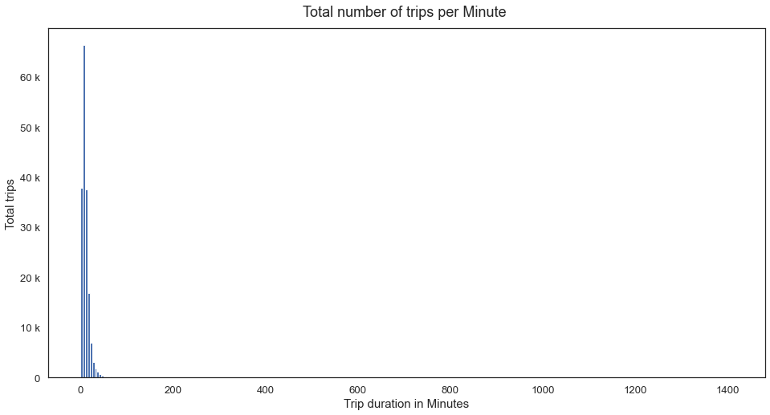

```python
# Define the size of the drawing
plt.figure(figsize = [16,8])


# Drawing texts are much larger
sb.set(font_scale=1.2)

# remove the grey background
sb.set_style("white")

# Convert seconds into minutes with rounding to the nearest integer
#df_bike['duration_min'] = round(df_bike['duration_sec'] / 60)

# Convert seconds into minutes
df_bike['duration_min'] = df_bike['duration_sec'] / 60

#Make every five minutes is bins
bins = np.arange(0, max(df_bike['duration_min']) + 1 , 5)
#bins = np.arange(0, 30 , 5)#set up bins

#plot
plt.hist(data = df_bike , x = 'duration_min' , bins = bins)
plt.gca().yaxis.set_major_formatter(matplotlib.ticker.EngFormatter());

plt.title('Total number of trips per Minute ',fontsize=18,pad=15)
plt.xlabel('Trip duration in Minutes',fontsize=15)
plt.ylabel('Total trips',fontsize=15);
```

> We got a long-tailed distribution that is also skewed to the right

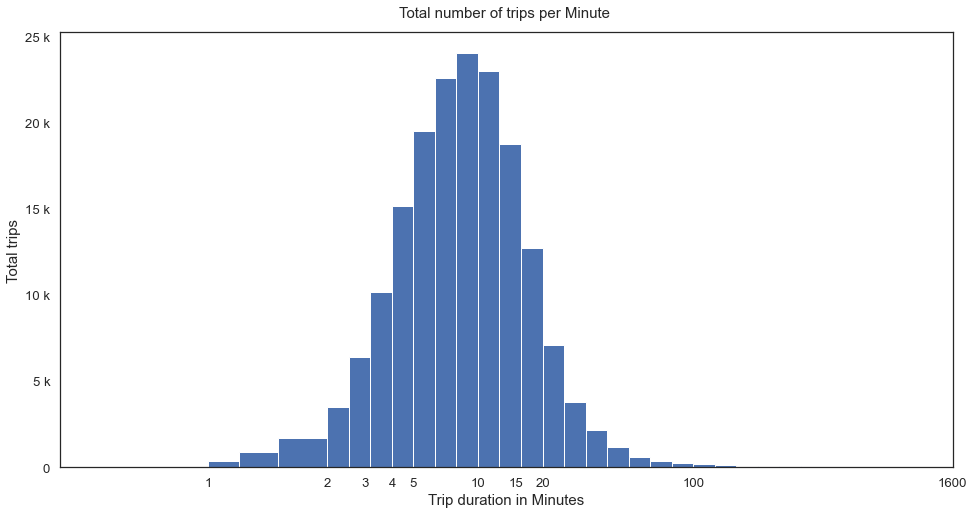

```python
# Define the size of the drawing
plt.figure(figsize = [16,8])

# Get the ticks for bins between [0 - maximum weight]
bins = 10 ** np.arange(-1, 3+0.1, 0.1)

# Generate the x-ticks you want to apply
ticks = [ 1, 2,3,4,5, 10, 15, 20, 100, 1600]

# Convert ticks into string values, to be displaye dlong the x-axis
labels = ['{}'.format(v) for v in ticks]

# Plot the histogram
plt.hist(data=df_bike, x='duration_min', bins=bins);

# The argument in the xscale() represents the axis scale type to apply.
plt.xscale('symlog')

plt.title('Total number of trips per Minute ',fontsize=15,pad=15)
plt.xlabel('Trip duration in Minutes',fontsize=15)
plt.ylabel('Total trips',fontsize=15);
plt.gca().yaxis.set_major_formatter(matplotlib.ticker.EngFormatter())

# Apply x-ticks
plt.xticks(ticks, labels);
```

> It appears clearly here that most of the trips are between 5 minutes and 15 minutes

### what Distribution of the number of trips by gender ?

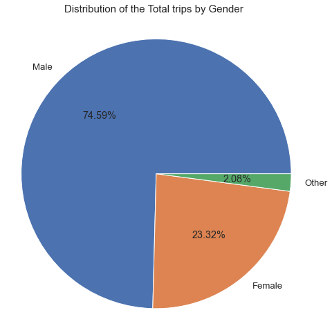

```python
# Define the size of the drawing
plt.figure(figsize=(16,8))

# Drawing texts are much larger
sb.set(font_scale=1.2)

# remove the grey background
sb.set_style("white")

#Calculating the total number of trips of the gender of users
utype_value_count = df_bike['member_gender'].value_counts()

plt.pie(utype_value_count, labels = utype_value_count.index, autopct='%1.2f%%');

plt.axis('square')
plt.title('Distribution of the Total trips by Gender ', fontsize=15,pad=15);
```

> It appears from the previous chart that most of the trips are made by males

### What is the total number of flights according to the type of members?

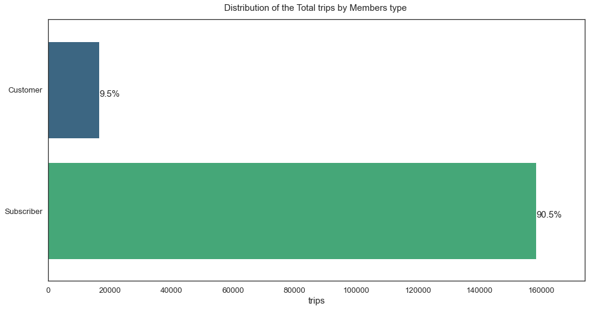

```python
# Define the size of the drawing
plt.figure(figsize = [16, 8]);
#Graph title
plt.title('Distribution of the Total trips by Members type ', fontsize=15,pad=15);


# Calculate the total number of users
df_bike_user_type = df_bike['user_type'].value_counts().sum()

#Arrange the values in descending order
type_counts = df_bike['user_type'].value_counts().sort_index()


#  print the text (proportion) on the bars
base_color = sb.color_palette()[0]

# Drawing texts are much larger
sb.set(font_scale=1.2)

# remove the grey background
sb.set_style("white")

sb.countplot(data=df_bike, y='user_type',palette='viridis');

# Logic to print the proportion text on the bars
for i in range (type_counts.shape[0]):
    count = type_counts[i]
    # Convert count into a percentage, and then into string
    pct_string ='{:0.01f}%'.format(100*count /df_bike_user_type);
    # Print the string value on the bar.
    plt.margins(0.10, 0.1);
    plt.text( count+1, i,  pct_string, va='top',   fontsize=15 );

plt.xlabel("trips",fontsize=15);
plt.ylabel("",fontsize=12);
```

> From the previous chart we have 90.5% of the total trips by subscribers

### How many users shared their data ?

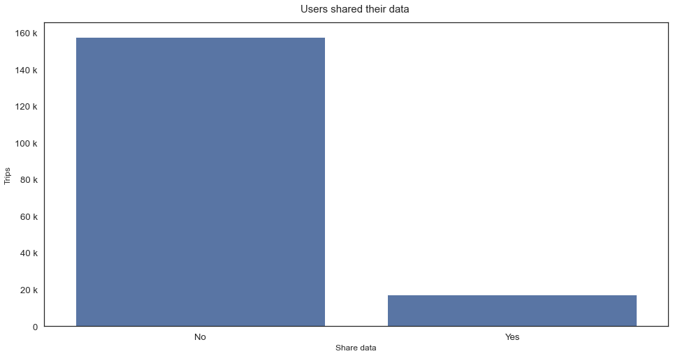

```python
# Define the size of the drawing
plt.figure(figsize = [16, 8])

#bar chart of gender
base_color = sb.color_palette()[0]

# Drawing texts are much larger
sb.set(font_scale=1.2)

# remove the grey background
sb.set_style("white")

#Graph title
plt.title('Users shared their data ', fontsize=15,pad=15);


sb.countplot(data=df_bike, x='bike_share_for_all_trip', color=base_color)
plt.gca().yaxis.set_major_formatter(matplotlib.ticker.EngFormatter())
plt.xlabel("Share data",fontsize=12)
plt.ylabel("Trips",fontsize=12)
plt.show()
```

> We note in the previous chart that users do not like to share trip data

### What is the age distribution on the number of trips?

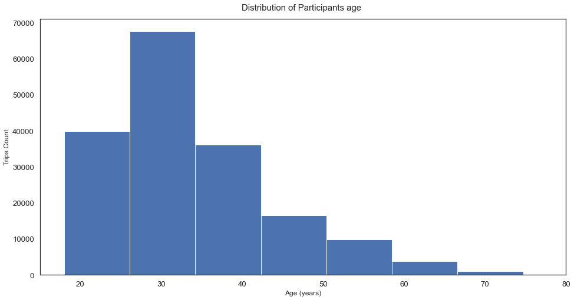

```python
#
bins_age = np.arange(18,141+5, 5 )

# Define the size of the drawing
plt.figure(figsize=(16, 8))
plt.hist(data=df_bike, x = 'age')
plt.xlim(15,80)

# Drawing texts are much larger
sb.set(font_scale=1.2)

# remove the grey background
sb.set_style("white")

#Graph title
plt.title('Distribution of Participants age ', fontsize=15,pad=15);
sb.set_style("white")
#add xlabel, ylabel and title
plt.xlabel("Age (years)",fontsize=12)
plt.ylabel("Trips Count",fontsize=12)
plt.show()
```

> We got a long-tailed distribution that is also skewed to the right

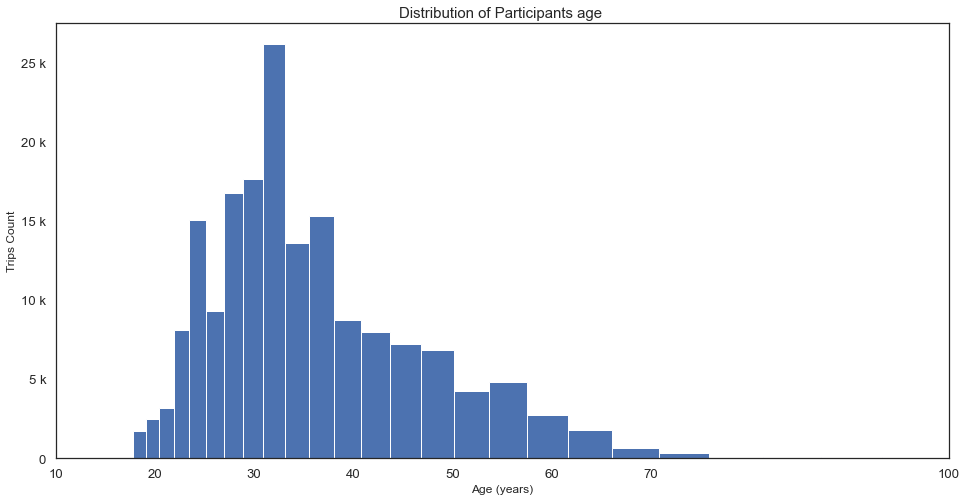

```python
#
bins = 10 ** np.arange(-1, 3+0.1, 0.03)
# Define the size of the drawing
plt.figure(figsize=(16, 8))

plt.hist(data=df_bike, x = 'age', bins=bins)
plt.xlim(15,80)

#Graph title
plt.title('Distribution of Participants age ', fontsize=15 );

# Drawing texts are much larger
sb.set(font_scale=1.2)

# remove the grey background
sb.set_style("white")

#add xlabel, ylabel
plt.xlabel("Age (years)",fontsize=12)
plt.ylabel("Trips Count",fontsize=12)

# Generate the x-ticks you want to apply
ticks = [ 10, 20,30,40,50, 60, 70, 100 ]

# Convert ticks into string values, to be displaye dlong the x-axis
labels = ['{}'.format(v) for v in ticks]
sb.set_style("white")
plt.gca().yaxis.set_major_formatter(matplotlib.ticker.EngFormatter())

# Apply x-ticks

plt.xticks(ticks, labels);

plt.show()
```

### What is the Total trips during the weekday?

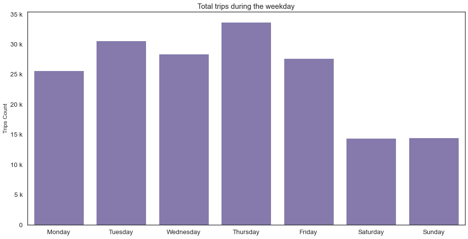

```python
#Convert the date to the  day name
df_bike['day'] =df_bike['start_time'].dt.day_name()
df_bike['day_of_week'] =df_bike['start_time'].dt.dayofweek
df_bike.sort_values('day_of_week', inplace=True)

# Define the size of the drawing
plt.figure(figsize = [16, 8])
base_color = sb.color_palette()[4]


# Drawing texts are much larger
sb.set(font_scale=1.2)

# remove the grey background
sb.set_style("white")
sb.countplot(data=df_bike, x='day', color=base_color)

#Graph title
plt.title(' Total trips during the weekday ', fontsize=15 );

#
plt.gca().yaxis.set_major_formatter(matplotlib.ticker.EngFormatter())

# xlabel, ylabel
plt.xlabel("", fontsize=12)
plt.ylabel("Trips Count", fontsize=12)
```

> Exactly the opposite of expected (weekend days are the least in the Total of Trips) The highest is Thursday and then Tuesday

### Discuss the distribution(s) of your variable(s) of interest. Were there any unusual points? Did you need to perform any transformations?

> I built the distribution around the number of trips against the duration of the trip, and also compared the busiest days. I also compared the trips of subscribers with the trips of customers, and also the number of trips based on the gender of the user. I took into account the comparison of users' behavior in sharing data.\ \ An interesting point when comparing the days of the week with the total number of trips, it was strange that the weekend is the least day in the number of trips.\ \ I made two transformations. The first was the total number of trips versus the duration of trips. I converted it into minutes to be more clear. Also, we got a long-tailed distribution that also tends to the right. I improved it. The second transformation was the age of the users versus the total number of trips. We got a long-tailed distribution that also tends to the right. I also improved it.

### Of the features you investigated, were there any unusual distributions? Did you perform any operations on the data to tidy, adjust, or change the form of the data? If so, why did you do this?

> There are trips that take a long time, but they do not affect the data in general and are considered outliers\ \ I added a column in the data to convert the date of birth to the age of the user, and also from adding a column to convert seconds into minutes, and I also added two columns, the first for the number of the day and the second for the name of the day in the week\ \ To make it easier for the audience to read, and also to make it easier to make comparisons and conclusions, I added the age column. I also added the trip duration column in minutes, that reduces the distraction caused by a large number of results from the seconds, so that it is easy for the audience to understand, easy to display and be more useful. I also added two columns with the number of the day in the week, and also the name of The day of the week Facilitating dealing with the days of the week and arranging them and presenting them to the public regarding the number of trips on each day of the week and their arrangement as well

## Bivariate Exploration ||

> In this section, investigate relationships between pairs of variables in your data. Make sure the variables that you cover here have been introduced in some fashion in the previous section (univariate exploration).

### what is the Relationship between the duration of the trip and Every type of user?

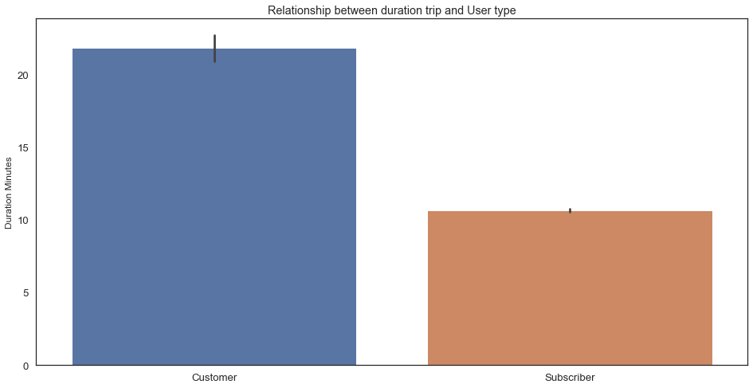

```python
# Define the size of the drawing
plt.figure(figsize = [16, 8])

# Drawing texts are much larger
sb.set(font_scale=1.2)

# remove the grey background
sb.set_style("white")

sb.barplot(data = df_bike, x = 'user_type', y = 'duration_min' )
plt.xticks(rotation=0)

plt.title('Relationship between duration trip and User type');
plt.xlabel("", fontsize=12)
plt.ylabel("Duration Minutes", fontsize=12)
plt.show()
```

> From the results above, it is noted that the duration of the customers' trip is higher than the duration of the subscribers' trip

### comparison of trips on weekdays vs user type, and member gender?

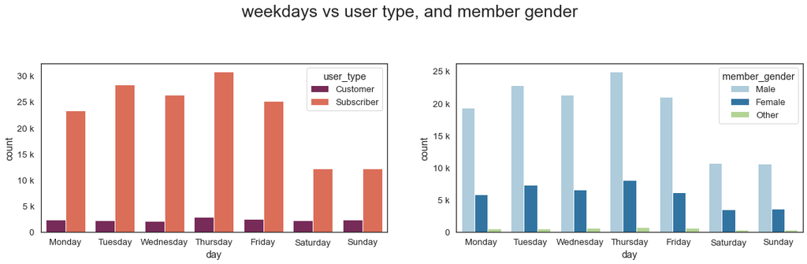

```python
# Define the size of the drawing
plt.figure(figsize = [20, 10])

#this for weekdays  vs user_type
plt.subplot(2, 2, 1)
plt.suptitle('weekdays vs user type, and member gender', fontsize=25, y=1)
sb.countplot(data = df_bike, x = 'day', hue = 'user_type', palette = 'rocket')
plt.gca().yaxis.set_major_formatter(matplotlib.ticker.EngFormatter())


#this for weekdays t vs member_gender
ax = plt.subplot(2, 2, 2)
sb.countplot(data = df_bike, x = 'day', hue = 'member_gender', palette = 'Paired')
plt.gca().yaxis.set_major_formatter(matplotlib.ticker.EngFormatter())


sb.set(font_scale=1.1)
plt.show()
```

> From the previous chart, it appears that there is no difference during the days of the week in the rate of trips between the gender and the type of user

### What is the relationship between age and the duration of the trip?

[figure not shown]

```python
# Define the size of the drawing
plt.figure(figsize = [20, 10])

# PLOT ON LEFT
plt.subplot(1, 2, 1)
plt.title('The relationship between trip duration and age', fontsize=15,pad=15)

# Drawing texts are much larger
sb.set(font_scale=1.2)

# remove the grey background
sb.set_style(style='white')


sb.regplot(data = df_bike, x = 'age', y = 'duration_min', truncate=False);
plt.ylabel('Age')
plt.xlabel('Duration (minutes)')


# PLOT ON RIGHT
plt.subplot(1, 2, 2)
plt.title('The relationship between trip duration and age', fontsize=15,pad=15)

# Drawing texts are much larger
sb.set(font_scale=1.2)

# remove the grey background
sb.set_style(style='white')

sb.regplot(data =  df_bike, x = 'duration_min', y = 'age', truncate=True, x_jitter=0.1);

plt.ylabel('Duration (minutes)')
plt.xlabel('Age')
```

### What is the distribution of user types and gender?

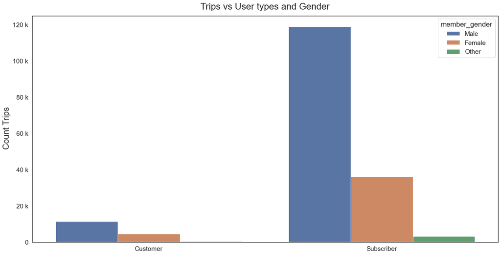

```python
# Define the size of the drawing
plt.figure(figsize = [20, 10])

# Drawing texts are much larger
sb.set(font_scale=1.4)

# remove the grey background
sb.set_style("white")

sb.countplot(data=df_bike, x= 'user_type', hue ='member_gender')
plt.title('Trips vs User types and Gender', fontsize=22,pad=15)

plt.gca().yaxis.set_major_formatter(matplotlib.ticker.EngFormatter())

plt.ylabel(' Count Trips' , fontsize=20);
plt.xlabel('');
```

> We note here that Male make more trips, whether subscribers or customers, than females, then others

### Talk about some of the relationships you observed in this part of the investigation. How did the feature(s) of interest vary with other features in the dataset?

> There is a correlation between the number of trips that meet the gender, whether they are involved or not. They do not intersect until the same behavior throughout the week

## Multivariate Exploration |||

> Create plots of three or more variables to investigate your data even further. Make sure that your investigations are justified, and follow from your work in the previous sections.

### Is there a difference in the Mean Trip Duration of the Weekdays with the types of users?

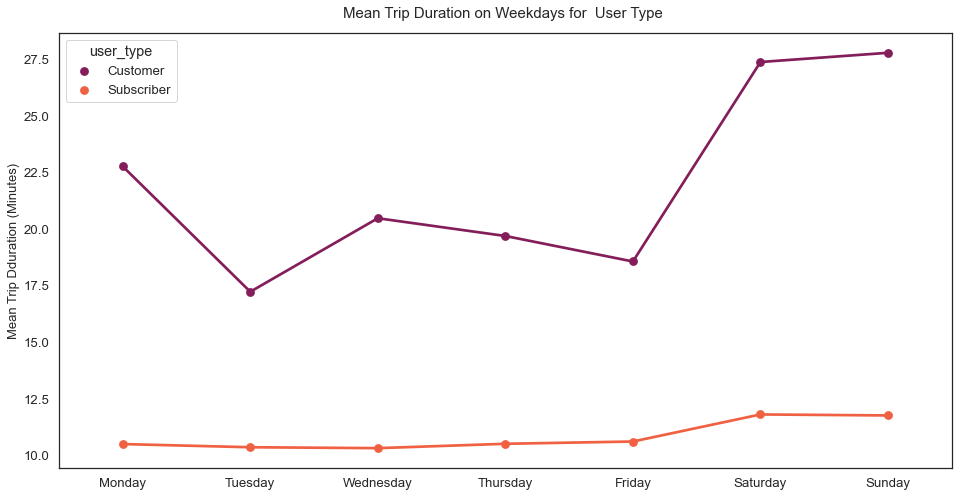

```python
# Define the size of the drawing
fig = plt.figure(figsize = [16,8])

# Drawing texts are much larger
sb.set(font_scale=1.2)

# remove the grey background
sb.set_style(style='white')

sb.pointplot(data = df_bike, x = 'day', y = 'duration_min', hue = 'user_type', palette = 'rocket', ci=None)

plt.title('Mean Trip Duration on Weekdays for  User Type ', fontsize=15,pad=15)
plt.ylabel('Mean Trip Dduration (Minutes)', fontsize=13)
plt.xlabel('')
plt.show();
```

> Completing our previous investigation, customer journey duration increases significantly on weekends and Mondays, while subscribers get a slight increase.

### Is there a difference in the Mean Trip Duration of the Weekdays with the Member Gender?

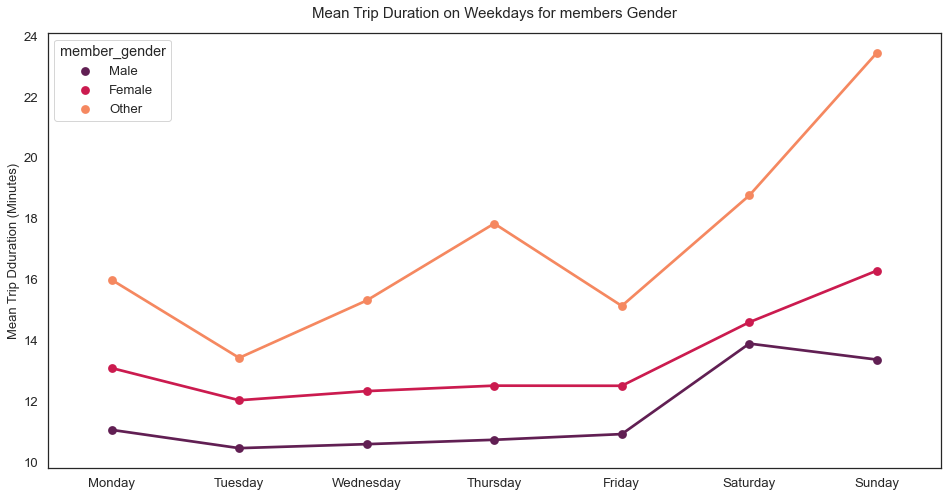

```python
# Define the size of the drawing
fig = plt.figure(figsize = [16,8])

# Drawing texts are much larger
sb.set(font_scale=1.2)
# remove the grey background

sb.set_style(style='white')
sb.pointplot(data = df_bike, x = 'day', y = 'duration_min', hue = 'member_gender',order=['Monday','Tuesday','Wednesday','Thursday','Friday','Saturday','Sunday'], palette="rocket", ci=None)

plt.title('Mean Trip Duration on Weekdays for members Gender', fontsize=15,pad=15)
plt.ylabel('Mean Trip Dduration (Minutes)', fontsize=13)
plt.xlabel('')
plt.show();
```

### Is there a difference in the average duration of the trip during the hours of the day with the types of users?

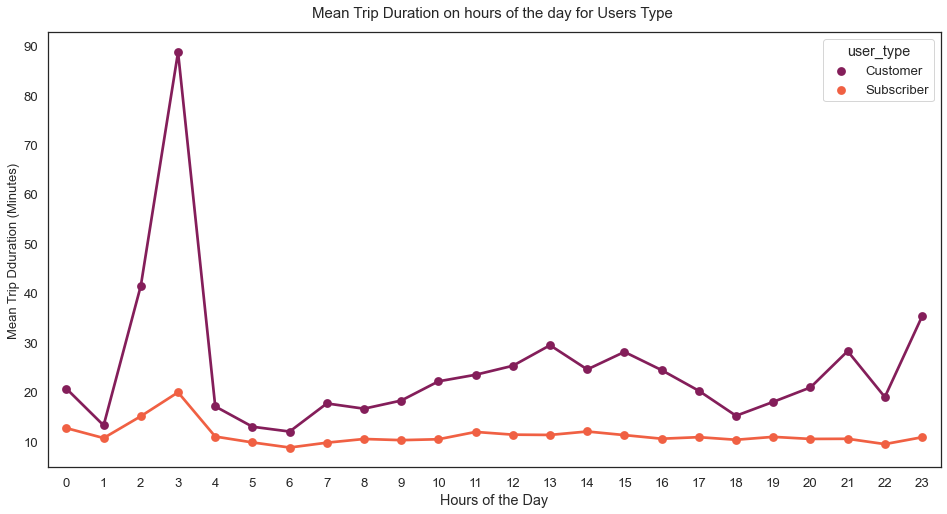

```python
#Add a starting hour column during the day
df_bike['start_hour'] =df_bike['start_time'].dt.hour

## Define the size of the drawing
fig = plt.figure(figsize = [16,8])

# Drawing texts are much larger
sb.set(font_scale=1.2)

# remove the grey background
sb.set_style(style='white')

sb.pointplot(data = df_bike, x = 'start_hour', y = 'duration_min', hue = 'user_type', palette = 'rocket', ci=None)

plt.title('Mean Trip Duration on hours of the day for Users Type ', fontsize=15,pad=15)
plt.ylabel('Mean Trip Dduration (Minutes)', fontsize=13)
plt.xlabel('Hours of the Day')
plt.show();
```

> Here we clearly see an increase in (Mean trip duration) for customers between 1 and 4 hours, and this is very interesting

### Is there a difference in the average duration of the trip during the hours of the day with the types of gender of the users?

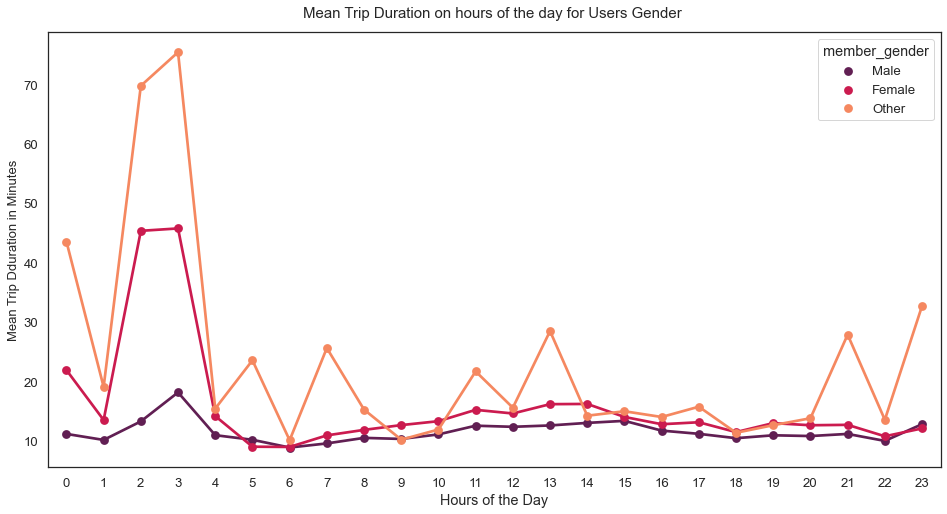

```python
# Define the size of the drawing
fig = plt.figure(figsize = [16,8])

# Drawing texts are much larger
sb.set(font_scale=1.2)
# remove the grey background
sb.set_style(style='white')
sb.pointplot(data = df_bike, x = 'start_hour', y = 'duration_min', hue = 'member_gender', palette = 'rocket', ci=None)

plt.title('Mean Trip Duration on hours of the day for Users Gender ', fontsize=15,pad=15)
plt.ylabel('Mean Trip Dduration in Minutes', fontsize=13)
plt.xlabel('Hours of the Day')
plt.show();
```

> Here we clearly see an increase in (Mean trip duration) for Female and Other between 1 and 4 hours, and this is very interesting

### Talk about some of the relationships you observed in this part of the investigation. Were there features that strengthened each other in terms of looking at your feature(s) of interest?

> I have an interest in the duration of the trip and whether it is affected by the type of user or the gender of the user during the days of the week or hours of the day.\ \ The results during the weekdays were: The average trip duration during Saturdays, Sundays, and Mondays for customers increased significantly, in contrast to the participants, the increase was very slight.\ \ And when comparing the days of the week with the gender of the users: there is an increase in the duration of the trip during Thursdays, Saturdays, and Sundays (non-specified) compared to males and females.\ \ For the results, compare the duration of the trip during the hours of the day with the type of user: There is a significant increase in the duration of the trip for customers between one hour and four hours compared to subscribers.\ \ And when compared to the gender of the user: There is a significant increase in the duration of the trip during the period from one hour to four hours. The duration of the trip increases significantly among women and (unspecified gender) compared to males.

### Were there any interesting or surprising interactions between features?

> There are interesting results, which is an increase in the duration of the trips between one hour and four o’clock compared to the type of users. Customers have a clear increase in the duration of the trip compared to subscribers in the duration of the trip. And when compared to the gender of the users, women and (non-specified) have an increase in the duration of the trip compared to males

```python
# data clean is for the second part ||

#df_bike.to_csv('201902-fordgobike-tripdata-clean.csv', encoding='utf-8')
```